# ECON3096 - Casual Inference

Assignment3

CHEN Ting

21 November, 2022

Let us load in the **wage.csv** data for Assignment 2.

```r
library(tidyverse)
library(haven)
library(sjPlot)
library(sjlabelled)
library(ggplot2)
read_csv("wage.csv")  -> wage # read the wage data file into R
```

A data frame containing 4360 observations on 36 variables.

- nr: Individual identifier;
- year: Year;
- wage: Log of hourly wage
- hours: Hourly wage ($)
- ag: Age;
- black: Black (=1);
- hisp: Hispanic (=1);
- exper: Years of experience;
- mar: Married (=1);
- school: Years of schooling;
- hlth: Has health disability (=1);
- union: Wage set by collective bargaining;
- rur: Lives in rural area;
- Regional dummies
- s: Lives in south
- ne: Lives in North East
- nc: Lives in Northern Central
- Industry dummies
- ag: Agricultural;
- min: Mining;
- con: Construction;
- trad: Trade;
- tra: Transportation;
- fin: Finance;
- bus: Business & Repair Service;
- per: Personal Service;
- ent: Entertainment;
- man: Manufacturing;
- pro: Professional & Related Service;
- pub: Public Administration;
- Occupational dummies
- OCC1: Professional, Technical and Kindred;
- OCC2: Managers, Officials and Proprietors;
- OCC3: Sales Workers;
- OCC4: Clerical and kindred;
- OCC5: Craftsmen, Foremen and kindred;
- OCC6: Operatives and kindred;
- OCC7: Laborers and farmers;
- OCC8: Farm Laborers and Foreman;
- OCC9: Service Workers.
1. Suppose we are now interested to find out whether union protection is useful to increase one’s wage, design several multivarate regression with control variables and a TWFE regression to test it. Report the results in a table and give your own interpretation. (Hints: Consider which variables might be correlated with joining a union and wage and add them as control varialbes)
2. Do the results from Q1 change if you use classical SEs, robust SEs, or clustered SEs at individual level? Please compare and provide your interpretations.
3. Plot the relationship between union and wage controlling for the TWFE. (Hints: Use anatomy regression to get residuals from TWFE)
4. From the following panel view plot, we can see that some individuals in our samples had never joined union and some were always union member throughout the observation period. What if we remove these two groups of individual (whose union status is always 0 or 1) and re-run the TWFE, does it provides us a different estimations? Check this out by running some additional regressions.

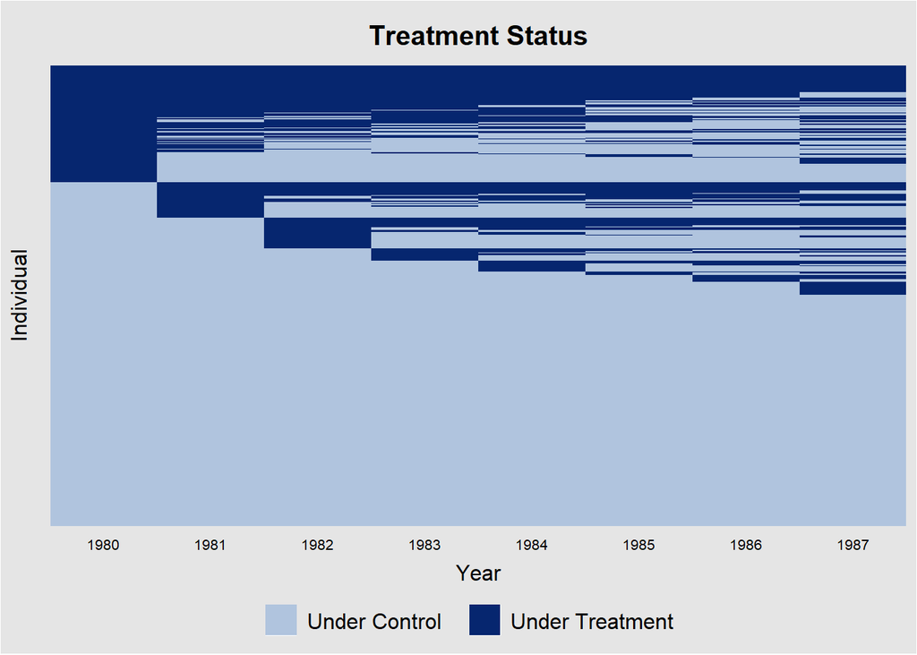

```r
library(panelView)
panelview(wage ~ union,
          data = wage, index = c("nr","year"),
          xlab = "Year", ylab = "Individual", by.timing = TRUE)
```

5. Does the effect of union protection on wage change over time? Design a regression to test it.
6. Among the 12 industries, which one union had the greatest power in terms of raising wage for its participants? Design a regression to answer this question. (Hints: Use interaction terms)